# Project3

Zhijun Liu

7/16/2020

# 1. Info

## description of data

[Attribute Information:](http://archive.ics.uci.edu/ml/datasets/Heart+failure+clinical+records)

Thirteen (13) clinical features:

- age: age of the patient (years)
- anaemia: decrease of red blood cells or hemoglobin (boolean)
- high blood pressure: if the patient has hypertension (boolean)
- creatinine phosphokinase (CPK): level of the CPK enzyme in the blood (mcg/L)
- diabetes: if the patient has diabetes (boolean)
- ejection fraction: percentage of blood leaving the heart at each contraction (percentage)
- platelets: platelets in the blood (kiloplatelets/mL)
- sex: woman or man (binary)
- serum creatinine: level of serum creatinine in the blood (mg/dL)
- serum sodium: level of serum sodium in the blood (mEq/L)
- smoking: if the patient smokes or not (boolean)
- time: follow-up period (days)
- [target] death event: if the patient deceased during the follow-up period (boolean)

# 5. Data

```r
# read in data
data <- read_csv("heart_failure_clinical_records_dataset.csv") %>%
  rename( "CPK"=creatinine_phosphokinase,
          "EF" = ejection_fraction,
          "HT" = high_blood_pressure,
          "creatinine" = serum_creatinine,
          "sodium" = serum_sodium,
          "death" = DEATH_EVENT) %>%
  mutate(survive = 1-death) %>% select (-"death")
factorData <- data

factorData$anaemia <- as.factor(factorData$anaemia)
factorData$diabetes <- as.factor(factorData$diabetes)
factorData$HT <- as.factor(factorData$HT)
factorData$sex <- as.factor(factorData$sex)
factorData$smoking <- as.factor(factorData$smoking)
factorData$survive <- as.factor(factorData$survive)

datatable(data)
```

|  | age | anaemia | CPK | diabetes | EF | HT | platelets | creatinine | sodium | sex | smoking | time | survive |
| --- | --- | --- | --- | --- | --- | --- | --- | --- | --- | --- | --- | --- | --- |
| 1 | 75 | 0 | 582 | 0 | 20 | 1 | 265000 | 1.9 | 130 | 1 | 0 | 4 | 0 |
| 2 | 55 | 0 | 7861 | 0 | 38 | 0 | 263358.03 | 1.1 | 136 | 1 | 0 | 6 | 0 |
| 3 | 65 | 0 | 146 | 0 | 20 | 0 | 162000 | 1.3 | 129 | 1 | 1 | 7 | 0 |
| 4 | 50 | 1 | 111 | 0 | 20 | 0 | 210000 | 1.9 | 137 | 1 | 0 | 7 | 0 |
| 5 | 65 | 1 | 160 | 1 | 20 | 0 | 327000 | 2.7 | 116 | 0 | 0 | 8 | 0 |
| 6 | 90 | 1 | 47 | 0 | 40 | 1 | 204000 | 2.1 | 132 | 1 | 1 | 8 | 0 |
| 7 | 75 | 1 | 246 | 0 | 15 | 0 | 127000 | 1.2 | 137 | 1 | 0 | 10 | 0 |
| 8 | 60 | 1 | 315 | 1 | 60 | 0 | 454000 | 1.1 | 131 | 1 | 1 | 10 | 0 |
| 9 | 65 | 0 | 157 | 0 | 65 | 0 | 263358.03 | 1.5 | 138 | 0 | 0 | 10 | 0 |
| 10 | 80 | 1 | 123 | 0 | 35 | 1 | 388000 | 9.4 | 133 | 1 | 1 | 10 | 0 |

[output cut: 289 more lines]

# 2. EDA

## categorical

### contigency table for select categorical variables

```r
table(data$anaemia,data$survive)
```

```
##
##       0   1
##   0  50 120
##   1  46  83
```

```r
table(data$diabetes,data$survive)
```

```
##
##       0   1
##   0  56 118
##   1  40  85
```

```r
table(data$HT,data$survive)
```

```
##
##       0   1
##   0  57 137
##   1  39  66
```

```r
table(data$sex,data$survive)
```

```
##
##       0   1
##   0  34  71
##   1  62 132
```

```r
table(data$smoking,data$survive)
```

```
##
##       0   1
##   0  66 137
##   1  30  66
```

### barchat

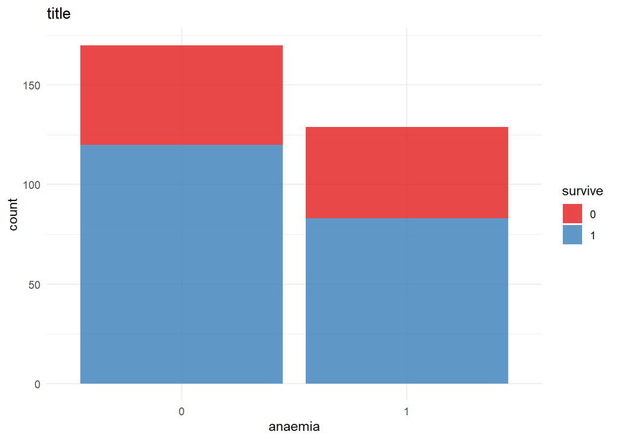

```r
# barchat for each
ggplot(data = factorData) +
  geom_bar(aes(x=anaemia,fill=survive),alpha=0.8) +
  scale_fill_brewer(palette="Set1")+
  labs(title='title')+
  theme_minimal()
```

## numeric

### statistic summaies for some numeric variable

*default: all numeric elements*

```r
data_numeric_summary <- data %>% select(age,CPK,EF,platelets,creatinine,sodium,time)

apply(X=data_numeric_summary,2,FUN=function(x){summary(x)})
```

```
##              age       CPK       EF platelets creatinine   sodium     time
## Min.    40.00000   23.0000 14.00000     25100    0.50000 113.0000   4.0000
## 1st Qu. 51.00000  116.5000 30.00000    212500    0.90000 134.0000  73.0000
## Median  60.00000  250.0000 38.00000    262000    1.10000 137.0000 115.0000
## Mean    60.83389  581.8395 38.08361    263358    1.39388 136.6254 130.2609
## 3rd Qu. 70.00000  582.0000 45.00000    303500    1.40000 140.0000 203.0000
## Max.    95.00000 7861.0000 80.00000    850000    9.40000 148.0000 285.0000
```

### correlation analysis for some elements

*default: all elements expect response*

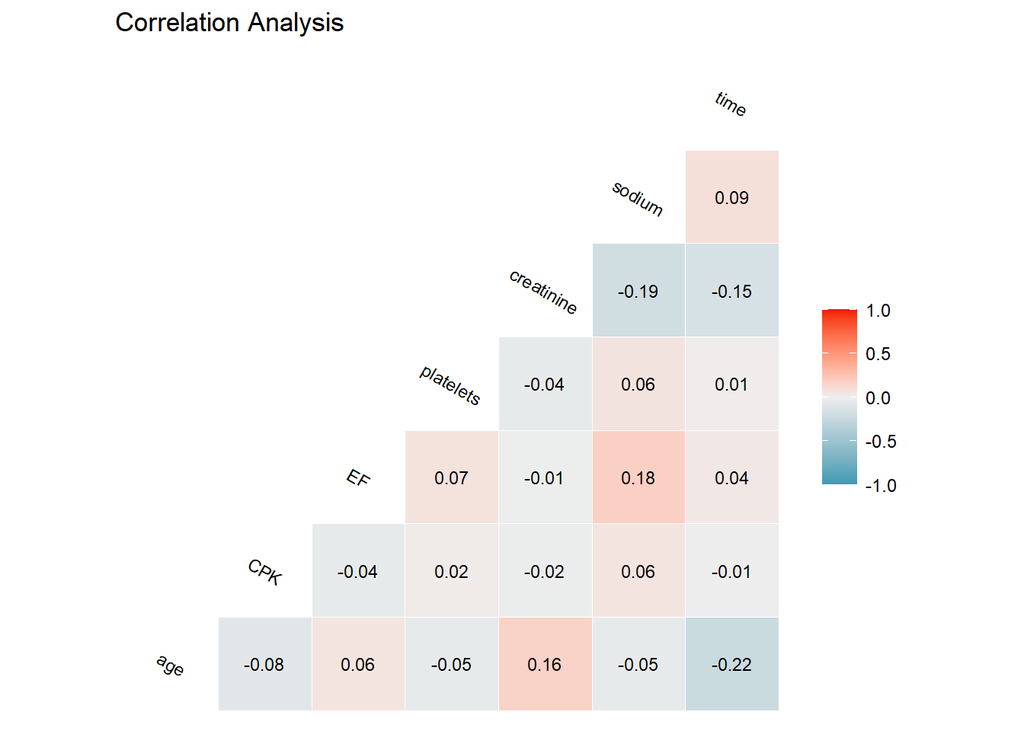

```r
library(ggplot2)
library(GGally)
ggcorr(factorData,label = T, label_size = 3, angle= -30, label_round = 2,size=3)+
  ggplot2::labs(title = "Correlation Analysis")
```

### scatter plot for some numeric elements

*default: all numeric elements*

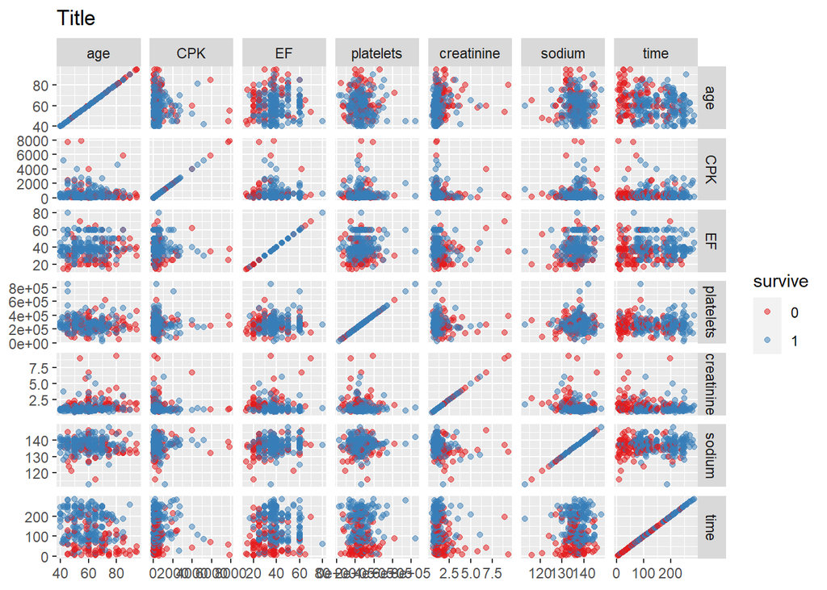

```r
data_numeric_scatter <- factorData %>% select(age,CPK,EF,platelets,creatinine,sodium,time,survive)

library(WVPlots)
PairPlot(data_numeric_scatter,
         colnames(data_numeric_scatter)[1:7],
         title="Title",
         group_var = "survive",
         alpha=0.5，
         palette="Set1")
```

*default: age*

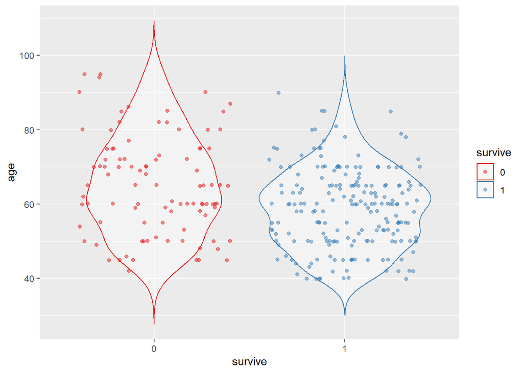

```r
data_numeric_box <- data_numeric_scatter
ggplot(data = data_numeric_box,aes(x=survive,y=age,color=survive))+
  geom_violin(trim=FALSE,alpha=0.4)+
  geom_point(alpha=0.5,position = "jitter")+
  scale_colour_brewer(palette="Set1")
```

```r
# CPK
# EF
# platelets
# creatinine
# sodium
# time
```

# 3. PCA

## Introduction

Principal components analysis (PCA) is a dimension reduction technique that is widely used in multivariate statistics. The objective is to condense the information that is present in the original set of variables via linear combinations of the variables while losing as little information as possible.

Typically, the number of linear transformations is much smaller than the number of original variables; hence the reduction in the dimensionality of the data. This can be useful in different ways, such as providing better visualization and computational advantages. PCA also decorrelates the data, that is, PCA produces linear combinations of the variables that are mutually uncorrelated.

Goal: Obtain a linear combination of the variables that accounts for the largest amount of variability (assume 0 mean for each predictor).

$$z_{i1} = \phi_{11}x_{i1}+ \phi_{21}x_{i2}+...+ \phi_{p1}x_{ip}$$
Constraint:

- $\Sigma^p_{j=1}\phi^2_{j1}=1$.
- $\mathop{max}\limits_{\phi's}\frac{1}{n}\Sigma^n_{i=1}z^2_{i1}$.
- PCs must be mutually exclusive.

## analysis

```r
data_numeric_pc <- data_numeric_summary
pc.out <- prcomp(data_numeric_pc,scale = T)
# referrence
summary(pc.out)
```

```
## Importance of components:
##                           PC1    PC2    PC3    PC4    PC5    PC6    PC7
## Standard deviation     1.2143 1.0842 1.0146 0.9830 0.9422 0.8587 0.8538
## Proportion of Variance 0.2107 0.1679 0.1471 0.1380 0.1268 0.1053 0.1041
## Cumulative Proportion  0.2107 0.3786 0.5257 0.6637 0.7905 0.8959 1.0000
```

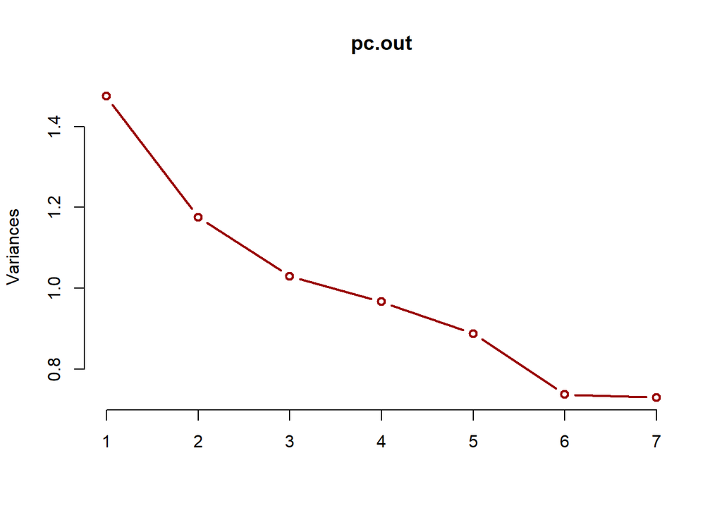

```r
screeplot(pc.out,type="lines",col="#990000",lwd=2)
```

```r
# rotation
round(pc.out$rotation[,1:3],3)
```

```
##               PC1    PC2    PC3
## age         0.465 -0.452  0.008
## CPK        -0.138  0.194 -0.815
## EF         -0.179 -0.681  0.107
## platelets  -0.199 -0.247 -0.403
## creatinine  0.512 -0.046 -0.102
## sodium     -0.447 -0.430 -0.118
## time       -0.481  0.214  0.371
```

```r
library(pca3d)
pca3d(pc.out,components = c(1,2,3),group=data$survive, legend="right")
```

```
## [1] 0.11360121 0.06409987 0.13983697
## Creating new device
```

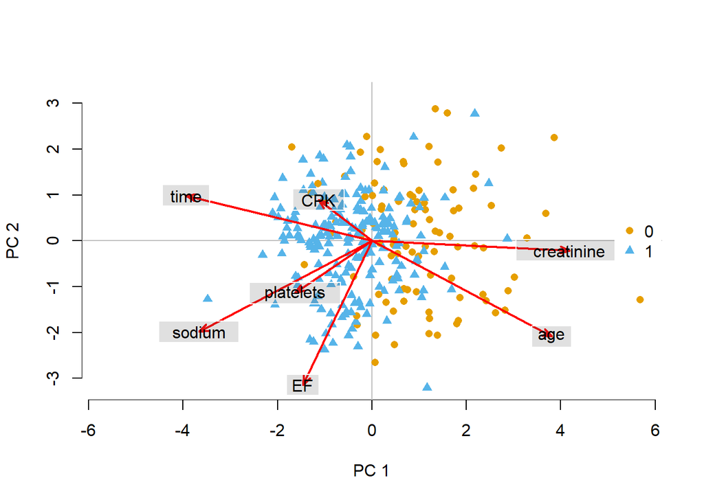

```r
# snapshotPCA3d(file="second_plot.png")
pca2d(pc.out,components = c(1,2),group=data$survive,biplot = T, biplot.vars = 7, legend="right")
```

# 4. Modelling

## Tree model

### Introduction

Classification tree if goal is to classify (predict) group membership.

For a binary response, within a given node (p=P(correct classification))

$$Deviance: -2plog(p)-2(1-p)log(1-p)$$

For all possible splits, minimize this (weighted appropriately for node size).

We need to pruned back using classification error rate to prevent overfit, which might increase bias but decrease variance, hopefully improving prediction.

### Analysis

```r
library(tree)
# fit the tree model
treeFit <- tree(survive ~ . ,data=factorData,split="deviance")
# result of tree model
summary(treeFit)
```

```
##
## Classification tree:
## tree(formula = survive ~ ., data = factorData, split = "deviance")
## Variables actually used in tree construction:
## [1] "time"       "sodium"     "EF"         "HT"         "creatinine"
## [6] "age"        "CPK"        "sex"        "diabetes"
## Number of terminal nodes:  18
## Residual mean deviance:  0.3798 = 106.7 / 281
## Misclassification error rate: 0.07692 = 23 / 299
```

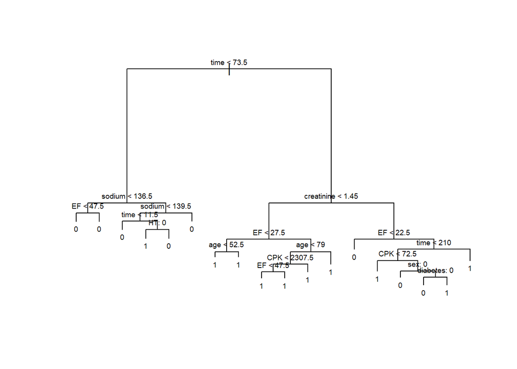

```r
# dendrogram
plot(treeFit)
text(treeFit, pretty = 0, cex = 0.6)
```

```r
# giveing the referrence result for choosing tree size
pruneFit <- cv.tree(treeFit, FUN = prune.misclass)
pruneFit
```

```
## $size
## [1] 18 12  8  2  1
##
## $dev
## [1] 65 66 56 54 96
##
## $k
## [1]      -Inf  0.000000  1.750000  2.666667 50.000000
##
## $method
## [1] "misclass"
##
## attr(,"class")
## [1] "prune"         "tree.sequence"
```

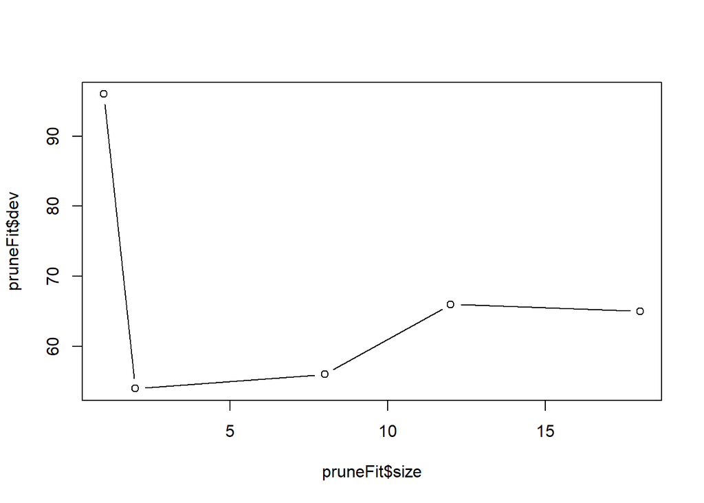

```r
# giveing the referrence plot for choosing tree size
plot(pruneFit$size,pruneFit$dev,type="b")
```

```r
pruneFitFinal <- prune.misclass(treeFit,best=8) # choose the tree size in best option
# user predict to change the variable value (need to split the categorical data and numeric data)
# predict(pruneFitFinal, newdata = data.frame(time=10, creatinine=2),type="class")
```

## Logistic Regression

### Introduction

Logistic regression is a statistical model that in its basic form uses a logistic function to model a binary dependent variable.

```r
glmFit <- glm(survive ~ ., data=factorData,family = "binomial")
glmFit
```

```
##
## Call:  glm(formula = survive ~ ., family = "binomial", data = factorData)
##
## Coefficients:
## (Intercept)          age     anaemia1          CPK    diabetes1           EF
##  -1.018e+01   -4.742e-02    7.470e-03   -2.222e-04   -1.451e-01    7.666e-02
##         HT1    platelets   creatinine       sodium         sex1     smoking1
##   1.027e-01    1.200e-06   -6.661e-01    6.698e-02    5.337e-01    1.349e-02
##        time
##   2.104e-02
##
## Degrees of Freedom: 298 Total (i.e. Null);  286 Residual
## Null Deviance:       375.3
## Residual Deviance: 219.6     AIC: 245.6
```

```r
summary(glmFit)
```

```
##
## Call:
## glm(formula = survive ~ ., family = "binomial", data = factorData)
##
## Deviance Residuals:
##     Min       1Q   Median       3Q      Max
## -2.6668  -0.4466   0.2401   0.5706   2.1848
##
## Coefficients:
##               Estimate Std. Error z value Pr(>|z|)
## (Intercept) -1.018e+01  5.657e+00  -1.801 0.071774 .
## age         -4.742e-02  1.580e-02  -3.001 0.002690 **
## anaemia1     7.470e-03  3.605e-01   0.021 0.983467
## CPK         -2.222e-04  1.779e-04  -1.249 0.211684
## diabetes1   -1.451e-01  3.512e-01  -0.413 0.679380
## EF           7.666e-02  1.633e-02   4.695 2.67e-06 ***
## HT1          1.027e-01  3.587e-01   0.286 0.774688
## platelets    1.200e-06  1.889e-06   0.635 0.525404
## creatinine  -6.661e-01  1.815e-01  -3.670 0.000242 ***
## sodium       6.698e-02  3.974e-02   1.686 0.091855 .
## sex1         5.337e-01  4.139e-01   1.289 0.197299
## smoking1     1.349e-02  4.126e-01   0.033 0.973915
## time         2.104e-02  3.014e-03   6.981 2.92e-12 ***
## ---
## Signif. codes:  0 '***' 0.001 '**' 0.01 '*' 0.05 '.' 0.1 ' ' 1
##
## (Dispersion parameter for binomial family taken to be 1)
##
##     Null deviance: 375.35  on 298  degrees of freedom
## Residual deviance: 219.55  on 286  degrees of freedom
## AIC: 245.55
##
## Number of Fisher Scoring iterations: 6
```

```r
# predict
# exp(predict(glmFit, newdata = data.frame(time=10, creatinine=2),type="link"))
```